# STA232Lab9

Po

3/9/2020

# MCEM

#### Goal

Find $\text{argmax}_\theta f(y|\theta)$ where $f(y| \theta) = \int f(y, \alpha| \theta) d\alpha$

Instead, find $\text{argmax}_\theta E_{\alpha | y} [f(y, \alpha|\theta)]$

#### EM algorithm

- E-Step  
  Construct the function $Q(\theta|\theta^{(k)}) := \text{E}( \log f(y, \alpha| \theta) | y, \theta^{(k)}) \approx \frac{1}{L}\sum_l \log f(y, \alpha_\text{MC}^{(l)} | \theta)$  
  where $\alpha_\text{MC}^{(l)}$’s are MCMC samples of $\alpha|y, \theta^{(k)}$

  Use MCMC algorithm such as Metropolis-Hastings. In general we can use NUTS https://mc-stan.org/users/interfaces/rstan.
- M-Step  
  $\theta^{(k+1)} = \text{argmax}_\theta Q(\theta|\theta^{(k)})$

  Use `optim` in R.

#### Metropolis-Hastings algorithm

Draw MCMC samples of $\alpha|y, \theta^{(k)}$.

https://en.wikipedia.org/wiki/Metropolis%E2%80%93Hastings_algorithm

Burin-in: Use the stationary sequence

Thining: Independent samples

#### Standard error estimation

standard errors of the MLEs – asymptotic covariance matrix – Fisher information matrix

Compute the observed Fisher information matrix for MCEM.

> Gelman, Andrew, and Xiao-Li Meng, eds. Applied Bayesian modeling and causal inference from incomplete-data perspectives. John Wiley & Sons, 2004. Page 256 equation (23.6)

```r
library(tidyverse)
library(lme4)
lamb <- read.csv(file = "lamb.csv") %>%
        mutate(Sire = factor(Sire),
               Line = factor(Line),
               Age  = factor(Age)
        )
lamb_reml <- lmer(Weight ~ 1 + (1|Sire), data = lamb)
y = getME(lamb_reml, "y")
X = getME(lamb_reml, "X")
Z = getME(lamb_reml, "Z")
r = 10

E_step <- function(theta, y, X, Z, r) {
  n = dim(Z)[1]
  k = dim(Z)[2]
  beta      <- theta$beta
  tau_sq    <- theta$tau_sq
  sigma_sq  <- theta$sigma_sq

  alpha_given_data = replicate(r, {
                          solve(t(Z)%*%Z/tau_sq + diag(k)/sigma_sq,
                                t(Z)%*%(y - X%*%beta + sqrt(tau_sq)*rnorm(n))/tau_sq
                          ) +sqrt(1/sigma_sq)*rnorm(k)
                     })
  fr = function(x) {
    mean(sapply(alpha_given_data, function(alpha) {
      sum((y - (X * x[1] * 2 + Z %*% alpha))^2) / x[2] + n*log(x[2]) + sum(alpha^2) / x[3] + k*log(x[3])
    }))
  }
  return(fr)
}

M_step <- function(fr, theta) {
  out = optim(c(theta$beta[1]/2, theta$tau_sq, theta$sigma_sq), fr,
              lower = 1e-10, upper = 20, method = "L-BFGS-B")
  return(list(beta=array(2*out$par[1], 1), tau_sq=out$par[2], sigma_sq=out$par[3], val = out$val))
}

# Initialization
theta = list(beta=array(mean(lamb$Weight), 1), tau_sq=sd(lamb$Weight)^2*0.5, sigma_sq=sd(lamb$Weight)^2*0.5)
for(i in 1:6){
  if(i==1) print(c("obj.", "beta", "tau_sq", "sigma_sq"))
  # E step
  qfun <- E_step(theta, y, X, Z, r+2*i)
  # M step
  theta <- M_step(qfun, theta)
  # Print result
  print(c(theta$val, theta$beta[1], theta$tau_sq, theta$sigma_sq))
}
```

```
## [1] "obj."     "beta"     "tau_sq"   "sigma_sq"
## [1] 164.161904  10.841532   2.890675   1.786800
## [1] 165.953639  11.020685   3.041477   1.684335
## [1] 159.201571  10.912613   2.896643   1.432166
## [1] 164.526798  10.957518   3.096585   1.508029
## [1] 165.259142  10.978454   3.166469   1.465907
## [1] 161.365803  10.895052   3.024494   1.400524
```

```r
summary(lamb_reml)
```

```
## Linear mixed model fit by REML ['lmerMod']
## Formula: Weight ~ 1 + (1 | Sire)
##    Data: lamb
##
## REML criterion at convergence: 250.6
##
## Scaled residuals:
##      Min       1Q   Median       3Q      Max
## -2.59653 -0.62476  0.08731  0.63045  2.26973
##
## Random effects:
##  Groups   Name        Variance Std.Dev.
##  Sire     (Intercept) 0.4349   0.6595
##  Residual             2.9783   1.7258
## Number of obs: 62, groups:  Sire, 23
##
## Fixed effects:
##             Estimate Std. Error t value
## (Intercept)  10.9596     0.2717   40.34
```

## GLMM

Finite Mixture Models for Proportions  
S. P. Brooks, B. J. T. Morgan, M. S. Ridout and S. E. Pack  
Biometrics Vol. 53, No. 3 (Sep., 1997), pp. 1097-1115 (19 pages)  
https://www.jstor.org/stable/2533567?seq=1#page_scan_tab_contents

Robust estimation in generalised linear mixed models  
Jiming Jiang Weihong Zhang  
Biometrika, Volume 88, Issue 3, 1 October 2001, Pages 753–765  
https://academic.oup.com/biomet/article/88/3/753/340112

The data set is fitted by generalized linear mixed model with Bernoulli response $y_{ij}$, $i = 1, \dots, 1328$, $j = 1, \dots, n_i$, where $n_i$ is the size of the $i$ th litter;

$y_{ij} = 1$ if the $j$ th implant in the $i$ th litter is dead, and $y_{ij} = 0$ otherwise.

The total number of responses is $N = \sum_{i = 1}^{1328} n_i = 10533$.

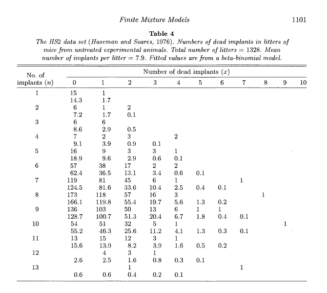

Ugly codes I had long time ago. It works but it is a bad example brute-force for-loop. Please use vectorized R codes.

```r
library(tidyverse)
library(lme4)

nlist <- list()
nlist[[1]] <- c(15,1)
nlist[[2]] <- c(6,1,2)
nlist[[3]] <- c(6,6)
nlist[[4]] <- c(7,2,3,NA,2)
nlist[[5]] <- c(16,9,3,3,1)
nlist[[6]] <- c(57,38,17,2,2)
nlist[[7]] <- c(119,81,45,6,1,NA,NA,1)
nlist[[8]] <- c(173,118,57,16,3,NA,NA,NA,1)
nlist[[9]] <- c(136,103,50,13,6,1,1)
nlist[[10]] <- c(54,51,32,5,1,NA,NA,NA,NA,1)
nlist[[11]] <- c(13,15,12,3,1)
nlist[[12]] <- c(NA,4,3,1)
nlist[[13]] <- c(NA,NA,1,NA,NA,NA,NA,1)

mice <- vector()
count <- 0
for (k in 1:13) {
  for (l in 1:length(nlist[[k]])) {
    if(!is.na(nlist[[k]][l]))
    {
      for (m in 1:nlist[[k]][l]) {
        count <- count + 1
        mice <- rbind(mice, c(l-1, k))
      }
    }
  }
}
mice = as.data.frame(mice)
names(mice) = c( "Ndead", "Nimplants")
mice$litter = 1:dim(mice)[1]
mice$litter = factor(mice$litter)
```

```r
print(head(mice, 20))
```

```
##    Ndead Nimplants litter
## 1      0         1      1
## 2      0         1      2
## 3      0         1      3
## 4      0         1      4
## 5      0         1      5
## 6      0         1      6
## 7      0         1      7
## 8      0         1      8
## 9      0         1      9
## 10     0         1     10
## 11     0         1     11
## 12     0         1     12
## 13     0         1     13
## 14     0         1     14
## 15     0         1     15
## 16     1         1     16
## 17     0         2     17
## 18     0         2     18
## 19     0         2     19
## 20     0         2     20
```

The link function is logit. The linear predictor is $\eta_{ij} = \mu + \alpha_i$, where $\alpha_1 , \dots, \alpha_m$ are random effects independent and distributed as $N (0, \sigma^2)$, and $\sigma$ and $\mu$ are unknown parameters.

The exponential family is Bernoulli distribution, with $P(y_{ij} = 1 | \alpha) = p_{ij}$. Therefore we have $y_{ij}$ conditionally independent such that
$$\text{logit} \{ P(y_{ij} = 1 | \alpha) \} = \mu + \alpha_i .$$

Find $\sigma$ and $\mu$ such that $\log f(y, \alpha| \mu, \sigma)$ is maximized.

```r
m1 <- glmer(cbind(Ndead, Nimplants-Ndead) ~ 1 + (1|litter), family = binomial, data = mice)
summary(m1)
```

```
## Generalized linear mixed model fit by maximum likelihood (Laplace
##   Approximation) [glmerMod]
##  Family: binomial  ( logit )
## Formula: cbind(Ndead, Nimplants - Ndead) ~ 1 + (1 | litter)
##    Data: mice
##
##      AIC      BIC   logLik deviance df.resid
##   3301.8   3312.2  -1648.9   3297.8     1326
##
## Scaled residuals:
##     Min      1Q  Median      3Q     Max
## -0.8860 -0.7851  0.0622  0.4711  3.1741
##
## Random effects:
##  Groups Name        Variance Std.Dev.
##  litter (Intercept) 0.4773   0.6908
## Number of obs: 1328, groups:  litter, 1328
##
## Fixed effects:
##             Estimate Std. Error z value Pr(>|z|)
## (Intercept) -2.29028    0.04568  -50.14   <2e-16 ***
## ---
## Signif. codes:  0 '***' 0.001 '**' 0.01 '*' 0.05 '.' 0.1 ' ' 1
```

#### Approximate integration

Here is an example to compute deviance of GLMM model. It gives you some hints on what actually happens in numerical integration to approximate the likelihood/deviance. https://github.com/lme4/lme4/blob/master/misc/logLikGLMM/logLikGLMM.R

The package `lme4` indeed uses Laplace approximation and Gaussian quadrature to do the MLE. You may utilize the package in fitting and analysis.

However, we should understand the methods and be able to explain the methods, not just treating the fit as a blackbox output and reporting merely numbers.

#### Sampling random effect given data and variance-compoment using MH

```r
mh_algorithm <- function(mydata, mu_current, sigma_current, init_sample, n_sample, n_burnin, n_thin) {
  n_alpha = dim(mydata)[1]
  gamma_func <- function(alpha_new, alpha_old) {
    pmin(1,
         ### acceptance probability
         ### output: array of size n_alpha
    )
  }
  candidate_func <- function(alpha_old) {
    ### jumping distribution
    ### output: array of size n_alpha
  }

  n <- n_thin*n_sample + n_burnin
  alpha_sample <- matrix(0.0, ncol = n, nrow = n_alpha)
  alpha_sample[,1] <- init_sample
  for (step in 2:n) {
    alpha_sample_candidate <- candidate_func(alpha_sample[, step-1])
    u <- runif(n_alpha)
    flag <- u < gamma_func(alpha_sample_candidate, alpha_sample[, step-1])
    alpha_sample[, step] <- alpha_sample_candidate * flag + alpha_sample[, step-1] * (1 - flag)
  }
  return(alpha.sample[,seq(n_burnin+1, n, by=n_thin)]) ## n_alpha by n_sample matrix
}
```

#### Sampling random effect given data and variance-compoment using MCMC software Stan

```r
library(rstanarm)

mu_current = -2.0
sigma_current = 0.8
litter_index = 500:1000

mice_sample = mice[litter_index,]
mice_sample$mu = rep(mu_current, dim(mice_sample)[1])
m_post <- stan_glm(cbind(Ndead, Nimplants-Ndead) ~ 0 + litter,
                   offset = mu,
                   prior = normal(0.0, sigma_current),
                   family = binomial,
                   data = mice_sample,
                   seed = 1997,
                   chains = 1,
                   keep_every = 2,
                   iter = 400)
```

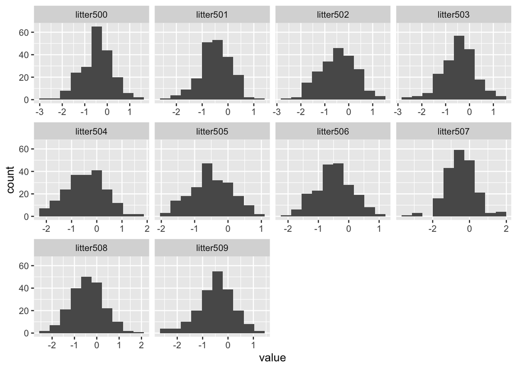

```r
ggplot(gather(as.data.frame(m_post)[,1:10]), aes(value))+
  geom_histogram(bins = 10) +
  facet_wrap(~key, scales = 'free_x')
```

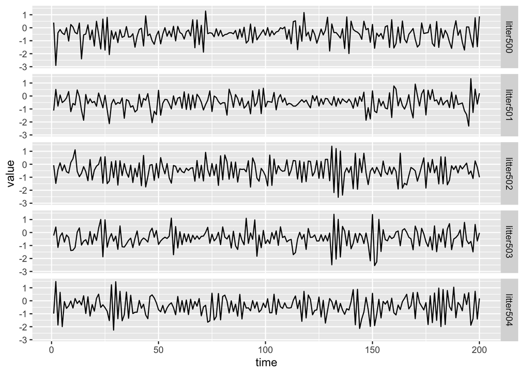

```r
library(reshape2)
df <- as.data.frame(m_post)[,1:5]
df$time = 1:dim(df)[1]
df <- melt(df,  id.vars = 'time', variable.name = 'series')
ggplot(df, aes(time,value)) + geom_line() + facet_grid(series ~ .)
```

It is okay to use MCMC methods other than Metropolis Hastings. Again, whatever method we use, we should understand what we are doing and explain it.